# BioSS - initiate agent

## Overview

The `roamR` package is S4-class based. At the basic level there is a general agent (here a simulated bird), which inherits properties from its species, and the moves around in an environment which consists of things like coastline boundaries, off-shore windfarms/structures etc. Here we describe the process to initiate agents i.e. create the simulated birds in preparation for spatio-temporal simulation.

This is described in the context of what BioSS needs to do for the WP3 uncertainty analysis. This distinct from running the simulation in a standard way, as the inputs will be varied in a structured fashion to investigate sensitivities. For BioSS’ purposes, the following will need varying over batches of simulation runs (as implied by the spreadsheet *ORJIP-DisNBS-Casestudyinputvalues-draftformAB31may2024_JAG_Guillemots.xlsx* in the project team files):

- SST: 3D data-cube, SST in C at x, y and numeric month
- Case-study species density maps: 3D data-cube, animal densities at x, y and numeric month
- Case-study species competitor maps: 3D data-cube, animal densities at x, y and numeric month
- (potential) species level variations:
  - Redistribution rate for footprint
  - Behavioural costs for activities flight/active/inactive/diving (NB colony excluded for these NBS simulations)
  - Initial body mass distribution
  - Initial activity budgets (proportion of time per day in each state)

Note:

- Impact scenarios are limited to one set of synthetic OWF footprints.
- Many of the inputs have explicit stochasticity associated, particularly at the species definition level (see below). Spatio-temporal data-cubes need stochasticity managed “outside” i.e. varied as inputs across simulations.

## Initial steps

Example data sourced by BioSS is found in the project sharepoint (`/DisNBS PSG - WP3/data`) and covers SST, conspecific distributions, target population distributions, and synthetic wind-farms. They are:

- `sst_file/sst.mnmean.nc` a netCDF file of global SST temperatures, monthly for more than a century.
- `/case study guillemot isle of may/CompetitionMaps/newrds` conspecific density maps in monthly `rds` files (covering 9 non-breeding months, indexed numercially 1-12 for months), consisting of 100 bootstraps within each. Provides spatial density maps.
- `/case study guillemot isle of may/GuillemotIsleOfMayDensityMaps` target population density maps, separate files for months and bootstraps (covering 9 non-breeding months, indexed numercially 1-12 for months asnd indexed 1-100 for boostraps). Provides spatial density maps.
- `/case study guillemot isle of may/WindfarmFootprints/Synthetic Polygons` shapefiles giving collection of polygons.

A BioSS branch of the `roamR` package can be found here ([roamR](https://www.dropbox.com/scl/fo/xr4855ffhvcvs9p6qgnpv/AP8m31z5MHT2oyoD_BwyKys?rlkey=rqcd3an2kqhs02xjhew7ey3ds&dl=0)). The package is in development - we will not install this branch `per se`, rather access directly i.e. open the package project () and use `devtools` to access the namespace.

```r
# initially required packages
library(tidyverse)
library(roamR)
library(stars)
library(sf)
library(distributional)
library(CircStats)
library(devtools)
# access the package elements
load_all()
```

```
ℹ Loading roamR
```

### Spatio-temporal inputs

The following are elements of the simulation data provided by BioSS. There is an Area of Calculation (AoC) which bounds the simulation spatially, and a common projection for all the spatial data. These are also/generally specified in the IBM config object (see later), but explicit here. The AoC is a reasonably large box (some 1000km x 800km) encompassing the Isle of May, and the coordinate system imposed here is UTM 30N - noting the underlying movement model operates on metres, so decimal lat/long for instance is inconvenient. The underlying density maps extend from the mediterranian sea into the arctic, which is larger than we reasonably require, and would incur some computational overhead.

```r
# UTM zone 30N
utm30 <- st_crs(32630)

# Input data layers -----------------------------------------------------------------------------------------------

density_map <- readRDS("data/GuillemotIsle of May3_iteration1.rds") %>%
  st_as_stars() %>%
  rename(pop_dens = X3)
dens_crop <- st_bbox(c(xmin = -5e5, ymin = -4e6,  xmax = 5e5, ymax = -3.2e6), crs = st_crs(density_map))

density_map <- st_crop(density_map, dens_crop)

competitor_map <- readRDS("data/competition_layer_conmap_UK9004171_3.rds") %>%
  st_as_stars() %>%
  rename(compet_dens = layer.1) %>%
  st_crop(dens_crop)

IFD_map <- (density_map + competitor_map) %>%
  rename(combined_dens = pop_dens)

footprints <- st_read("data/Synthetic Polygons/") %>%
  st_transform(st_crs(density_map)) %>%
  st_crop(dens_crop)
```

One requirement is a coastline, as the agents move at sea. There is an overhead in initialising this, although it need only be done once at the start (coastlines being constant). The following is a simple coastline that works well computationally.

```r
coastline <- ggplot2::map_data("world", region = "UK") |>
  st_as_sf(coords = c("long", "lat"),  crs = 4326) |>
  group_split(group) |>
  purrr::map(\(x){
    st_combine(x) |>
      st_cast("POLYGON")
  } ) |>
  purrr::list_c() |>
  st_combine() %>%
  st_transform(st_crs(density_map)) %>%
  st_crop(dens_crop)
```

In total, our simulation is operating in an environment like the following - coast, OWF and densities.

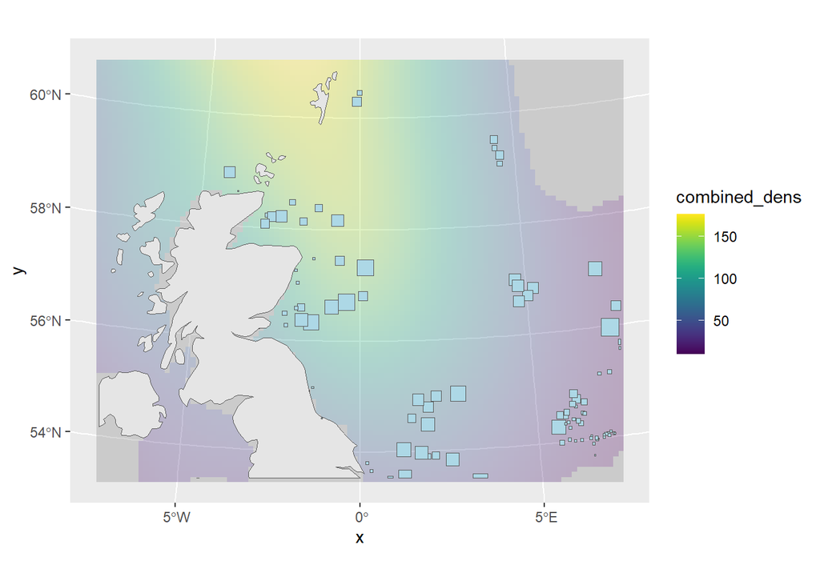

```r
ggplot(coastline) +
  viridis::scale_fill_viridis() +
  geom_stars(data = IFD_map, aes(fill = combined_dens), alpha = 0.3) +
  geom_sf() +
  geom_sf(data = footprints, fill = "lightblue")
```

SST is similarly required, principally for the calculation of energetics in our example. The data is global, over a long time frame, an awkward coordinate systen, and is quite coarse. To use this for our example (where at the scale of the Isle of May there is no SST data) we impute to avoid gaps. Here it is a mean imputation as an example, but ought to be treated more thoroughly.

```r
sst <- stars::read_ncdf("data/sst.mnmean.nc") %>%
  filter(time == "2023-12-01")
```

```
no 'var' specified, using sst
```

```
other available variables:
 lat, lon, time_bnds, time
```

```
0-360 longitude crossing the international date line encountered.
Longitude coordinates will be 0-360 in output.
```

```
Will return stars object with 33642000 cells.
```

```
No projection information found in nc file.
 Coordinate variable units found to be degrees,
 assuming WGS84 Lat/Lon.
```

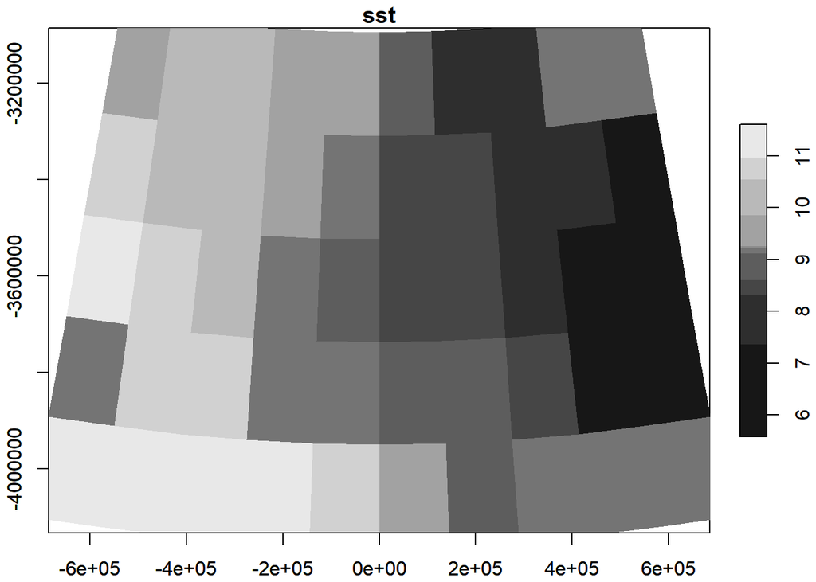

```r
# address the coordinate system
source("tools/sst-to-aoc.R")


# crop to AOC: dec lat/long
sst_aoc <- dens_crop %>%
  st_transform(4326)

# due to such low res, we need to interpolate - a fancy model would be best, here just mean
sst_crop <- st_crop(sst, sst_aoc)
sst_crop$sst <- ifelse(is.na(sst_crop$sst), mean(sst_crop$sst, na.rm = T), sst_crop$sst)

sst_crop <- sst_crop %>%
  st_transform(st_crs(density_map))

plot(sst_crop, axes = T)
```

## IBM initialisation

The objective here is to create an individual agent, in preparation for interacting with its environment. `roamR` attempts to be quite general and covers complex cases - we’ll include aspects in the initialisation that we won’t actively use.

### high-level IBM configuration

Here we’re seeking to initiate a single agent and run this with direct control over its inputs. Generally the IBM will be prepared for large numbers of agents, all run internally with one call to the initialised objects. We need to specify high-level elements before creating an agent:

- A start/finish location and times for the non-breeding season i.e. the colony we’re simulating the population for. Here the Isle of May.
- Common projections/coordinate system to impose.
- Time steps for revising activity budgets
- Raster resolutions
- Area of Calculation (AoC)

Here we’re running for 9 months, reassessing activity budgets daily, for a colony based at the Isle of May, UTM 30N projection, and basic 1km^2 resolution where needed.

```r
# IBM settings -------------------------------------------------

isle_may <- st_sf(
  id = "Isle of May",
  prop = 1,
  geom = st_sfc(st_point(c(-2.5667, 56.1833))),
  crs = 4326
)


# IBM Settings - modify parameter values to your specific case
guill_imb_config <- ModelConfig(
  n_agents = 1,
  ref_sys = utm30,
  aoc_bbx = dens_crop |> st_transform(utm30) |>  st_bbox(), #
  delta_x = 1000,
  delta_y = 1000,
  time_step = "1 day",
  start_date = date("2025-07-01"),
  end_date = date("2025-07-01") + 240, # ~9 months
  start_sites = isle_may |> st_transform(utm30),
  end_sites = isle_may |> st_transform(utm30)
)
```

### Influencers on movement (drivers)

The framework allows for various things to influence animal movement in complex ways, which are referred to as drivers. For our simulation only three will be influential: the bounding box of the simulation (AoC), the coastline and the location of the OWF. In general there might be complex inputs and reactions of the agent to these. These enter into the `Species` class, so are structurally associated with the population being simulated. Although the term “species” is used, they could be different for populations of the same species. Some of the agent’s properties flow from these, when assigned to that species.

```r
# Set up IBM drivers ----------------------------------------------------------------------------------------------

sst_drv <- Driver(
  id = "sst",
  type = "habitat",
  descr = "Sea Surface Temperature",
  stars_obj = sst_crop %>% st_transform(utm30)
)

coast_drv <- Driver(
  id = "land",
  type = "habitat",
  descr = "Coastline",
  sf_obj = coastline %>% st_transform(utm30)
)

owf_drv <- Driver(
  id = "owf_foot",
  type = "impact",
  descr = "OWF footprints",
  sf_obj = footprints %>% st_transform(utm30)
)

# store as list for initialisation
guill_drivers <- list(
  sst = sst_drv,
  coast = coast_drv,
  owf = owf_drv
)
```

The agent’s response to these can be functionally related e.g. via the distance from an OWF. While we’re not requiring anything complex here, a couple of simple effects are specified - the birds tend to move over the ocean, and may not enter the OWF footprint if they are sensitive to these.

```r
# Response to drivers  -------------------------------------------------

driver_resp <- list(
  coast = DriverResponse(
    driver_id = "land",
    movement = MoveInfluence(
      prob = VarDist(1),
      fn = function(x, slope = 1/2) exp(-slope * x),
      type = "repulsion"
    )),
  owf = DriverResponse(
    driver_id = "owf_foot",
    movement = MoveInfluence(
      prob = VarDist(dist_beta(2, 8)), # made-up
      fn = function(x, slope = 1/2) exp(-slope * x),
      type = "repulsion"
    ))
)
```

### Activity and energetics

The energetics of the agents are dictated by the time spent in particular states and the environment they are operating in. These will be populated with more care later, in particular diving, but as an initial pass these are populated. There are currently 3 main components, beyond settling on the total possible states. Each state has state movement properties, an amount of the day spent in the state (note these are converted to proportions and balanced behind the scenes, with due consideration of units), and parameters for the energy calculations.

```r
# States specification -------------------------------------------------

states <- list(
  flight = State(
    id = "flight",
    energy_cost = VarDist(dist_normal(141, 66), units = "kJ/hour/gram"), # vals from excel sheet. Normal not adequate as it will generate negative values - needs reparameterization to logN
    time_budget = VarDist(dist_uniform(0, 0.15), "hours/day"), # roughly based on Lila's summaries
    speed = VarDist(dist_uniform(10, 20), "m/s") # made-up
),
dive = State(
  id = "diving",
  energy_cost = VarDist(dist_normal(200, 10), units = "kJ/hour/gram"), # made-up
  time_budget = VarDist(dist_uniform(2.5, 3.5), "hours/day"), # roughly based on Lila's summaries
  speed = VarDist(dist_uniform(0, 1), "m/s") # made-up
),
active = State(
  id = "active_on_water",
  energy_cost = VarDist(dist_normal(150, 10), units = "kJ/hour/gram"), # made-up
  time_budget = VarDist(dist_uniform(10, 11), "hours/day"), # roughly based on Lila's summaries
  speed = VarDist(dist_uniform(0, 1), "m/s") # made-up
),
inactive = State(
  id = "inactive_on_water",
  energy_cost = VarDist(dist_normal(150, 10), units = "kJ/hour/gram"), # made-up
  time_budget = VarDist(dist_uniform(10, 11), "hours/day"), # roughly based on Lila's summaries
  speed = VarDist(dist_uniform(0, 1), "m/s") # made-up
),
colony = State(
  id = "colony",
  energy_cost = VarDist(dist_normal(33.8, 11.4), units = "kJ/hour/gram"), # vals from excel sheet
  time_budget = VarDist(0, "hours/day"), # no time at colony
  speed = VarDist(0, "m/s") # made-up
)
)
```

In addition to response to drivers, and state specifications, there are several simpler parameters for the species class. In particular, the size of the “species” population i.e. the simulated population (used as a weighting factor when the number of simulated animals $\ne$ colony size), the distribution of initial body masses, body weight below which agents die and other labelling.

```r
# Specify <Species>  -------------------------------------------------

guill <- Species(
  id = "guill",
  common_name = "guillemot",
  scientific_name = "Uria Aalge",
  pop_size = 15000,
  body_mass_distr = VarDist(dist_uniform(600, 1450), "g"),
  mortality_thresh_distr = VarDist(800, "g"),
  states_profile = states,
  driver_responses = driver_resp
)
```

## Initialise the IBM

The configuration, drivers and species classes collectively define the IBM - which is initialised with `rmr_initiate`. This starts a number of checks, puts data into appropriate structures and calculates elements for the movement drivers. This can be time consuming, but is only required to be done once. The simulation function wrapper for the BioSS runs will make minimal direct changes to IBM elements - so re-initialisation is not required. The main calculations made by `rmr_initiate` relate inputs that are temporally invariant over a breeding season - coastline and OWFs.

```r
# Initiate Agent  -------------------------------------------------

guill_ibm <- rmr_initiate(
  species = guill,
  drivers = guill_drivers,
  model_config = guill_imb_config
)
```

```
ℹ Validating inputs
```

```
✔ Validating inputs [81ms]
```

```
ℹ Processing the AOC
```

```
✔ Processing the AOC [5.5s]
```

```
ℹ Calculate vector fields for movement drivers
```

```
✔ Calculate vector fields for movement drivers [22.2s]
```

```
ℹ Initialize Agents
```

```
✔ Initialize Agents [467ms]
```

```
ℹ Initialize <IBM> object
```

```
✔ Initialize <IBM> object [170ms]
```

```
★ All DONE!
```

## Create an agent

An instance of an agent/simulated bird is via `Agent`, requiring the species definition and model configuration.

```r
simBird <- Agent(species = guill, model_config = guill_imb_config)
```

This agent contains three main slots to govern its:

- current “state”, e.g. position, behaviour, direction, body mass etc (`@condition`)
- properties assigned specifically to that agent at initialisation, inherited from the species definition e.g. things tha influence it, initial weight, start and finish locations etc (`@properties`)
- evaluations of the condition over the course of the simulation (`@history`)

Currently the agent class accommodates:

```r
str(simBird)
```

```
Formal class 'Agent' [package "roamR"] with 3 slots
  ..@ condition :Formal class 'AgentCondition' [package "roamR"] with 13 slots
  .. .. ..@ location          : 'XY' num [1:2] 526896 6226565
  .. .. ..@ grid_cell         : 'XY' num [1:2] NA NA
  .. .. ..@ timestep          : int 0
  .. .. ..@ timestamp         : POSIXct[1:1], format: "2025-07-01"
  .. .. ..@ body_mass         : Units: [g] num 1415
  .. .. ..@ states_budget     :List of 5
  .. .. .. ..$ flight  : Units: [1] num 0.00293
  .. .. .. ..$ dive    : Units: [1] num 0.141
  .. .. .. ..$ active  : Units: [1] num 0.433
  .. .. .. ..$ inactive: Units: [1] num 0.423
  .. .. .. ..$ colony  : Units: [1] num 0
  .. .. ..@ states_cost       :List of 5
  .. .. .. ..$ flight  : Units: [kJ/g/h] num 0
  .. .. .. ..$ dive    : Units: [kJ/g/h] num 0
  .. .. .. ..$ active  : Units: [kJ/g/h] num 0
  .. .. .. ..$ inactive: Units: [kJ/g/h] num 0
  .. .. .. ..$ colony  : Units: [kJ/g/h] num 0
  .. .. ..@ energy_expenditure: Units: [kJ/g] num 0
  .. .. ..@ foraging_success  : Units: [g/d] num 0
  .. .. ..@ mass_change_value : Units: [g] num 0
  .. .. ..@ mortality_prob    : num NA
  .. .. ..@ alive             : logi TRUE
  .. .. ..@ track             :Classes 'sf' and 'data.frame':   1 obs. of  2 variables:
  .. .. .. ..$ timestamp: POSIXct[1:1], format: NA
  .. .. .. ..$ geom     :sfc_POINT of length 1; first list element:  'XY' num [1:2] NA NA
  .. .. .. ..- attr(*, "sf_column")= chr "geom"
  .. .. .. ..- attr(*, "agr")= Factor w/ 3 levels "constant","aggregate",..: NA
  .. .. .. .. ..- attr(*, "names")= chr "timestamp"
  ..@ properties:Formal class 'AgentProperties' [package "roamR"] with 10 slots
  .. .. ..@ species_id      : chr "guill"
  .. .. ..@ initial_mass    : Units: [g] num 1415
  .. .. ..@ speeds          :List of 5
  .. .. .. ..$ flight           : Units: [m/s] num 10.6
  .. .. .. ..$ diving           : Units: [m/s] num 0.0999
  .. .. .. ..$ active_on_water  : Units: [m/s] num 0.816
  .. .. .. ..$ inactive_on_water: Units: [m/s] num 0.802
  .. .. .. ..$ colony           : Units: [m/s] num 0
  .. .. ..@ start_point     : 'XY' num [1:2] 526896 6226565
```

[output cut: 12 more lines]

```
  .. .. ..@ age             : Units: [1] num NA
  .. .. ..@ sex             : chr NA
  ..@ history   :Classes 'sf' and 'data.frame': 1 obs. of  9 variables:
  .. ..$ timestep              : int 0
  .. ..$ body_mass             : Units: [g] num 1415
  .. ..$ states_budget.flight  : Units: [1] num 0.00293
  .. ..$ states_budget.dive    : Units: [1] num 0.141
  .. ..$ states_budget.active  : Units: [1] num 0.433
  .. ..$ states_budget.inactive: Units: [1] num 0.423
  .. ..$ states_budget.colony  : Units: [1] num 0
  .. ..$ energy_expenditure    : Units: [kJ/g] num 0
  .. ..$ geometry              :sfc_POINT of length 1; first list element:  'XY' num [1:2] 526896 6226565
  .. ..- attr(*, "sf_column")= chr "geometry"
  .. ..- attr(*, "agr")= Factor w/ 3 levels "constant","aggregate",..: NA NA NA NA NA NA NA NA
  .. .. ..- attr(*, "names")= chr [1:8] "timestep" "body_mass" "states_budget.flight" "states_budget.dive" ...
```